# Introduction

Introduction My name is Jongbo Bisola Tolutope and in this project,i will be analyzing insurance claims and my findings from this analysis will be used to build,train and test predict model based on the insurance data

# About The Project

I have been appointed as the Lead Data Analyst to build a predictive model to determine if a building will have an insurance claim during a certain period or not. I will have to predict the probability of having at least one claim over the insured period of the building. The model will be based on the building characteristics. The target variable, Claim, is a:

1 if the building has at least a claim over the insured period. 0 if the building doesn’t have a claim over the insured period.

# End-to-End Machine Learning Workflow

I will begin with data cleaning by identifying and addressing issues such as inconsistent naming conventions, missing values, incorrect data types, duplicates, and outliers to the best of my ability. Next, I will perform exploratory data analysis to understand how different features influence the target variable and to identify the most relevant features for the model. Finally, I will train and evaluate the model to ensure it performs as expected.

# Import Libraries

```python
 import warnings
warnings.filterwarnings('ignore')
#Data Analysis and Visualization
import numpy as np
import pandas as pd
import seaborn as sns
import matplotlib.pyplot as plt

#Modelling
from sklearn.linear_model import LogisticRegression
from sklearn.tree import DecisionTreeClassifier
from sklearn.ensemble import RandomForestClassifier
from sklearn.ensemble import GradientBoostingClassifier

#Pre-processing
from sklearn.model_selection import train_test_split
from sklearn.preprocessing import StandardScaler
#Hyperparameter tuning
from sklearn.model_selection import GridSearchCV
from sklearn.model_selection import RandomizedSearchCV

#Evalation
from sklearn.metrics import precision_score, recall_score, f1_score,roc_auc_score,accuracy_score

#Saving the model
import joblib
```

# Load data

```python
data= pd.read_csv(r'C:\Users\User\Documents\Data Science Capstone project\Train_data.csv')
```

# Exploratory Analysis

```python
data.head()
```

|  | Customer Id | YearOfObservation | Insured_Period | Residential | Building_Painted | Building_Fenced | Garden | Settlement | Building Dimension | Building_Type | Date_of_Occupancy | NumberOfWindows | Geo_Code | Claim |
| --- | --- | --- | --- | --- | --- | --- | --- | --- | --- | --- | --- | --- | --- | --- |
| 0 | H14663 | 2013 | 1.0 | 0 | N | V | V | U | 290.0 | 1 | 1960.0 | . | 1053 | 0 |
| 1 | H2037 | 2015 | 1.0 | 0 | V | N | O | R | 490.0 | 1 | 1850.0 | 4 | 1053 | 0 |
| 2 | H3802 | 2014 | 1.0 | 0 | N | V | V | U | 595.0 | 1 | 1960.0 | . | 1053 | 0 |
| 3 | H3834 | 2013 | 1.0 | 0 | V | V | V | U | 2840.0 | 1 | 1960.0 | . | 1053 | 0 |
| 4 | H5053 | 2014 | 1.0 | 0 | V | N | O | R | 680.0 | 1 | 1800.0 | 3 | 1053 | 0 |

```python
data.info()
```

```
<class 'pandas.core.frame.DataFrame'>
RangeIndex: 7160 entries, 0 to 7159
Data columns (total 14 columns):
 #   Column              Non-Null Count  Dtype
---  ------              --------------  -----
 0   Customer Id         7160 non-null   object
 1   YearOfObservation   7160 non-null   int64
 2   Insured_Period      7160 non-null   float64
 3   Residential         7160 non-null   int64
 4   Building_Painted    7160 non-null   object
 5   Building_Fenced     7160 non-null   object
 6   Garden              7153 non-null   object
 7   Settlement          7160 non-null   object
 8   Building Dimension  7054 non-null   float64
 9   Building_Type       7160 non-null   int64
 10  Date_of_Occupancy   6652 non-null   float64
 11  NumberOfWindows     7160 non-null   object
 12  Geo_Code            7058 non-null   object
 13  Claim               7160 non-null   int64
dtypes: float64(3), int64(4), object(7)
memory usage: 783.2+ KB
```

```python
data.describe()
```

|  | YearOfObservation | Insured_Period | Residential | Building Dimension | Building_Type | Date_of_Occupancy | Claim |
| --- | --- | --- | --- | --- | --- | --- | --- |
| count | 7160.000000 | 7160.000000 | 7160.000000 | 7054.000000 | 7160.000000 | 6652.000000 | 7160.000000 |
| mean | 2013.669553 | 0.909758 | 0.305447 | 1883.727530 | 2.186034 | 1964.456404 | 0.228212 |
| std | 1.383769 | 0.239756 | 0.460629 | 2278.157745 | 0.940632 | 36.002014 | 0.419709 |
| min | 2012.000000 | 0.000000 | 0.000000 | 1.000000 | 1.000000 | 1545.000000 | 0.000000 |
| 25% | 2012.000000 | 0.997268 | 0.000000 | 528.000000 | 2.000000 | 1960.000000 | 0.000000 |
| 50% | 2013.000000 | 1.000000 | 0.000000 | 1083.000000 | 2.000000 | 1970.000000 | 0.000000 |
| 75% | 2015.000000 | 1.000000 | 1.000000 | 2289.750000 | 3.000000 | 1980.000000 | 0.000000 |
| max | 2016.000000 | 1.000000 | 1.000000 | 20940.000000 | 4.000000 | 2016.000000 | 1.000000 |

```python
data.dtypes
```

```
Customer Id            object
YearOfObservation       int64
Insured_Period        float64
Residential             int64
Building_Painted       object
Building_Fenced        object
Garden                 object
Settlement             object
Building Dimension    float64
Building_Type           int64
Date_of_Occupancy     float64
NumberOfWindows        object
Geo_Code               object
Claim                   int64
dtype: object
```

# Data Cleaning

```python
#Using unique values from previous steps,
#Building_painted should be a mapped categorical column and not just a string object. It will be useful in modelling later
building_painted_map = {"V": "not_painted", "N": "painted"}
data["Building_Painted"] = data["Building_Painted"].map(building_painted_map)
data["Building_Painted"] = data["Building_Painted"].astype("category")

#Building_fenced will be treated similarly to building_painted
building_fenced_map = {"V": "not_fenced", "N": "fenced"}
data["Building_Fenced"] = data["Building_Fenced"].map(building_fenced_map)
data["Building_Fenced"] = data["Building_Fenced"].astype("category")

#Garden also gets similar treatment
garden_map = {"V": "has_garden", "O": "no_garden", np.nan: "Unknown"}
data["Garden"] = data["Garden"].map(garden_map)
data["Garden"] = data["Garden"].astype("category")

# Settlement
settlement_map = {"U": "urban", "R": "rural"}
data["Settlement"] = data["Settlement"].map(settlement_map)
data["Settlement"] = data["Settlement"].astype("category")
```

```python
#Missing values
data.isna().sum()
```

```
Customer Id             0
YearOfObservation       0
Insured_Period          0
Residential             0
Building_Painted        0
Building_Fenced         0
Garden                  0
Settlement              0
Building Dimension    106
Building_Type           0
Date_of_Occupancy     508
NumberOfWindows         0
Geo_Code              102
Claim                   0
dtype: int64
```

```python
#Dropping missing NAN
data.dropna(inplace=True)
```

```python
#confirming nans are dropped
House.isna().sum()
```

[output not shown]

```python
#Check duplicates
data.duplicated().sum()
```

```
0
```

```python
#Want to replace .  and >=10 to 10 in 	NumberOfWindows to zero
data['NumberOfWindows'].unique()
```

```
array(['   .', '4', '3', '2', '5', '10', '6', '7', '9', '8', '1'],
      dtype=object)
```

```python
data['NumberOfWindows'] = data['NumberOfWindows'].replace(r"   .",('0'), regex=True)
```

```python
#Replacing >=10 to 10
data['NumberOfWindows'] = data['NumberOfWindows'].replace(r'>=10','10', regex=True)
```

```python
#confirming the replacement
data['NumberOfWindows'].unique()
```

```
array(['0', '4', '3', '2', '5', '10', '6', '7', '9', '8', '1'],
      dtype=object)
```

```python
#Change datatype
data = data.astype({'Date_of_Occupancy':'int',
                        'Building Dimension':'int','NumberOfWindows':'int'})
```

```python
data.dtypes
```

```
Customer Id             object
YearOfObservation        int64
Insured_Period         float64
Residential              int64
Building_Painted      category
Building_Fenced       category
Garden                category
Settlement            category
Building Dimension       int32
Building_Type            int64
Date_of_Occupancy        int32
NumberOfWindows          int32
Geo_Code                object
Claim                    int64
dtype: object
```

```python
#Check for outliers since no duplicates were found

numerical_cols = data.select_dtypes(include=[np.number]).columns
for col in numerical_cols:
    outliers = data[(data[col] < data[col].quantile(0.01)) | (data[col] > data[col].quantile(0.99))]
    print(f"Outliers in {col}:")
    print(outliers)

#Since outliers exist within a reasonable and realistic range, we will not modify them
```

```
Outliers in YearOfObservation:
Empty DataFrame
Columns: [Customer Id, YearOfObservation, Insured_Period, Residential, Building_Painted, Building_Fenced, Garden, Settlement, Building Dimension, Building_Type, Date_of_Occupancy, NumberOfWindows, Geo_Code, Claim]
Index: []
Outliers in Insured_Period:
Empty DataFrame
Columns: [Customer Id, YearOfObservation, Insured_Period, Residential, Building_Painted, Building_Fenced, Garden, Settlement, Building Dimension, Building_Type, Date_of_Occupancy, NumberOfWindows, Geo_Code, Claim]
Index: []
Outliers in Residential:
Empty DataFrame
Columns: [Customer Id, YearOfObservation, Insured_Period, Residential, Building_Painted, Building_Fenced, Garden, Settlement, Building Dimension, Building_Type, Date_of_Occupancy, NumberOfWindows, Geo_Code, Claim]
Index: []
Outliers in Building Dimension:
     Customer Id  YearOfObservation  Insured_Period  Residential  \
109        H4555               2014        1.000000            0
112        H6126               2013        1.000000            0
180        H5724               2015        0.580822            1
187       H19770               2015        0.260274            0
208        H5245               2014        1.000000            0
...          ...                ...             ...          ...
6952      H17606               2013        1.000000            1
6953      H17607               2014        1.000000            1
6956       H4355               2012        1.000000            0
6957       H7378               2012        1.000000            0
6958       H7379               2015        1.000000            0

     Building_Painted Building_Fenced      Garden Settlement  \
109           painted      not_fenced  has_garden      urban
112           painted      not_fenced  has_garden      urban
180       not_painted      not_fenced  has_garden      urban
187       not_painted          fenced   no_garden      rural
208           painted      not_fenced  has_garden      urban
...               ...             ...         ...        ...
6952      not_painted          fenced   no_garden      rural
6953      not_painted          fenced   no_garden      rural
6956          painted      not_fenced  has_garden      urban
6957      not_painted      not_fenced  has_garden      urban
6958      not_painted      not_fenced  has_garden      urban

      Building Dimension  Building_Type  Date_of_Occupancy  NumberOfWindows  \
```

[output cut: 77 more lines]

```
5908    83144      0
6077    89291      0
6167    91182      0
6216    91691      0
6569    93007      0

[88 rows x 14 columns]
Outliers in NumberOfWindows:
Empty DataFrame
Columns: [Customer Id, YearOfObservation, Insured_Period, Residential, Building_Painted, Building_Fenced, Garden, Settlement, Building Dimension, Building_Type, Date_of_Occupancy, NumberOfWindows, Geo_Code, Claim]
Index: []
Outliers in Claim:
Empty DataFrame
Columns: [Customer Id, YearOfObservation, Insured_Period, Residential, Building_Painted, Building_Fenced, Garden, Settlement, Building Dimension, Building_Type, Date_of_Occupancy, NumberOfWindows, Geo_Code, Claim]
Index: []
```

# Vusalization

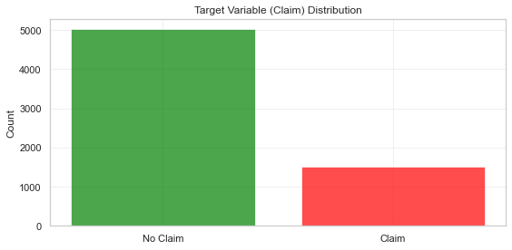

```python
#Now to visualize distributions
#Set up the visualization style

sns.set(style="whitegrid")

#Display target variable distributions

claim_counts = data["Claim"].value_counts()
claim_percent = claim_counts/len(data["Claim"] * 100)

#Plot the visuals
plt.figure(figsize=(8, 4))
bars = plt.bar(['No Claim', 'Claim'], claim_counts.values, color=['green', 'red'], alpha=0.7)
plt.title("Target Variable (Claim) Distribution")
plt.ylabel('Count')
plt.grid(True, alpha=0.3)
plt.tight_layout()
plt.show()
```

```python
#Feature importance is next
#Check the numerical features, while ignoring the "claim" column to see if they actually have correlation with the target variable

cols = data.select_dtypes(include = np.number).columns.to_list()
#Excluding claim
cols = [col for col in numerical_cols if col != "Claim" ]

#Calculatete correlations
correlations = []
for col in cols:
    if col in data.columns:
        real = data[[col, "Claim"]].dropna()
        if len(real) > 10:  # Need enough data
            corr = real.corr().iloc[0, 1]
            correlations.append({
                'Feature': col,
                'Correlation': corr,
                'Abs_Correlation': abs(corr),
                'Samples': len(real)
            })

corr_df = pd.DataFrame(correlations).sort_values('Abs_Correlation', ascending=False)

print("Top 10 Features by Absolute Correlation with Claim:")
for i, row in corr_df.head(10).iterrows():
    direction = "positive" if row['Correlation'] > 0 else "negative"
    strength = "strong" if abs(row['Correlation']) > 0.3 else "moderate" if abs(row['Correlation']) > 0.1 else "weak"
    print(f"{row['Feature']:25} {row['Correlation']:7.3f} ({direction}, {strength}) - {row['Samples']} samples")
```

```
Top 10 Features by Absolute Correlation with Claim:
Building Dimension          0.299 (positive, moderate) - 6550 samples
NumberOfWindows             0.141 (positive, moderate) - 6550 samples
Building_Type               0.114 (positive, moderate) - 6550 samples
Insured_Period              0.102 (positive, moderate) - 6550 samples
Residential                 0.067 (positive, weak) - 6550 samples
Date_of_Occupancy           0.019 (positive, weak) - 6550 samples
YearOfObservation          -0.017 (negative, weak) - 6550 samples
```

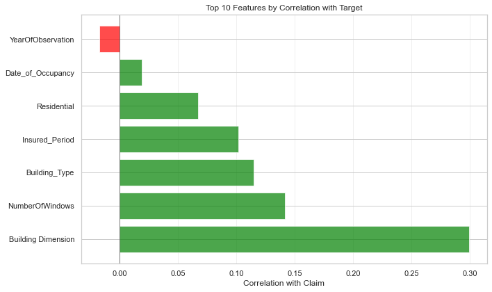

```python
# Simple correlation bar chart
plt.figure(figsize=(10, 6))
top_features = corr_df.head(10)
colors = ['red' if x < 0 else 'green' for x in top_features['Correlation']]
bars = plt.barh(range(len(top_features)), top_features['Correlation'], color=colors, alpha=0.7)
plt.yticks(range(len(top_features)), top_features['Feature'])
plt.xlabel('Correlation with Claim')
plt.title('Top 10 Features by Correlation with Target')
plt.grid(True, alpha=0.3, axis='x')
plt.axvline(x=0, color='black', linewidth=0.5)
plt.tight_layout()
plt.show()
```

# Discussion

It would be interesting to see how all these features come together to influence the performance of the model.

# Correlation

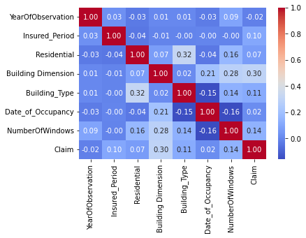

```python
#Correlation Analysis
Corr=data.corr()
sns.heatmap(Corr,annot=True,fmt=".2f",cmap="coolwarm")
plt.show()
```

# Split data into x and y

```python
#Splitting into train and test
x = data.drop('Claim', axis=1)
y = data['Claim']
```

```python
#One-Hot Encoding Using Pandas
x = pd.get_dummies(x, drop_first=True)
```

```python
x.dtypes
```

```
YearOfObservation       int64
Insured_Period        float64
Residential             int64
Building Dimension      int32
Building_Type           int64
                       ...
Geo_Code_95563          uint8
Geo_Code_95582          uint8
Geo_Code_95585          uint8
Geo_Code_95598          uint8
Geo_Code_95607          uint8
Length: 7814, dtype: object
```

```python
x_train , x_test ,y_train , y_test=  train_test_split(x , y , test_size=0.2 , random_state=42,stratify=y)#stratify=y keeps class balance
```

# Feature Scaling

```python
scaler = StandardScaler()
x_train = scaler.fit_transform(x_train)
x_test = scaler.transform(x_test)
```

# Creating Model

We will start simple and use hyperparameter tuning as necessary to ensure that we get the best model.

```python
#Create Model
model = LogisticRegression(
    class_weight='balanced',
    C=0.3,
    solver='liblinear'
)
```

```python
model = LogisticRegression()
```

# Train Model

```python
model.fit(x_train,y_train)
```

[output not shown]

# Prediction

```python
y_predict=model.predict(x_test)
```

# Evaluation

```python
accuracy = accuracy_score(y_test, y_predict)
precision = precision_score(y_test, y_predict)
recall = recall_score(y_test, y_predict)
f1 = f1_score(y_test, y_predict)
print("Accuracy:", accuracy)
print("Precision:", precision)
print("Recall:", recall)
print("F1-score:", f1)
```

```
Accuracy: 0.7692895339954163
Precision: 0.5
Recall: 0.0695364238410596
F1-score: 0.12209302325581393
```

```python
accuracy = accuracy_score(y_test, y_predict)
precision = precision_score(y_test, y_predict)
recall = recall_score(y_test, y_predict)
f1 = f1_score(y_test, y_predict)
print("Accuracy:", accuracy)
print("Precision:", precision)
print("Recall:", recall)
print("F1-score:", f1)
```

```
Accuracy: 0.7639419404125286
Precision: 0.4578313253012048
Recall: 0.12582781456953643
F1-score: 0.19740259740259739
```

# Confirm class imbalance

```python
y.value_counts(normalize=True)
```

```
0    0.769066
1    0.230934
Name: Claim, dtype: float64
```

# Create Model

```python
model = DecisionTreeClassifier(
    criterion='gini',      # or 'entropy'
    max_depth=5,           # controls overfitting
    random_state=42
)
```

# Train Model

```python
model.fit(x_train,y_train)
```

```
DecisionTreeClassifier(max_depth=5, random_state=42)
```

# Prediction

```python
y_pred = model.predict(x_test)
```

# Evaluation

```python
accuracy = accuracy_score(y_test, y_predict)
precision = precision_score(y_test, y_predict)
recall = recall_score(y_test, y_predict)
f1 = f1_score(y_test, y_predict)
print("Accuracy:", accuracy)
print("Precision:", precision)
print("Recall:", recall)
print("F1-score:", f1)
```

```
Accuracy: 0.7639419404125286
Precision: 0.4578313253012048
Recall: 0.12582781456953643
F1-score: 0.19740259740259739
```

# Confirm class imbalance

```python
y.value_counts(normalize=True)
```

```
0    0.769066
1    0.230934
Name: Claim, dtype: float64
```

# Create the Gradient Boosting Classifier

# Create Model

```python
model = GradientBoostingClassifier(
    n_estimators=50,     # number of trees
    learning_rate=0.1,   # step size
    max_depth=3,         # depth of each tree
    random_state=42
)
```

# Train Model

```python
model.fit(x_train, y_train)
```

```
GradientBoostingClassifier(n_estimators=50, random_state=42)
```

# Make Prediction

```python
y_pred = model.predict(x_test)
```

# Evaluation

```python
accuracy = accuracy_score(y_test, y_predict)
cm = confusion_matrix(y_test, y_predict)
report = classification_report(y_test, y_predict)
f1=f1_score(y_test,y_predict)
precision_score = (y_test,y_predict)
recall=recall_score(y_test,y_predict)

print("Accuracy:", accuracy)
print("precision_score:", precision_score)
print("recall_score:", recall_score)
print("f1:", f1)
print("Confusion Matrix:\n", cm)
print("Classification Report:\n", report)
```

```
Accuracy: 0.7692895339954163
precision_score: (1368    1
2532    0
1017    0
6787    0
3678    0
       ..
160     0
5360    0
7050    0
2923    0
2523    0
Name: Claim, Length: 1309, dtype: int64, array([0, 0, 0, ..., 0, 0, 0], dtype=int64))
recall_score: <function recall_score at 0x0000020119C98040>
f1: 0.12209302325581393
Confusion Matrix:
 [[986  21]
 [281  21]]
Classification Report:
               precision    recall  f1-score   support

           0       0.78      0.98      0.87      1007
           1       0.50      0.07      0.12       302

    accuracy                           0.77      1309
   macro avg       0.64      0.52      0.49      1309
weighted avg       0.71      0.77      0.70      1309
```

# Radom Forest Model

```python
RandomForestClassifier(
    n_estimators=300,
    max_depth=10,
    min_samples_split=10,
    class_weight='balanced',
    random_state=42
)
```

```
RandomForestClassifier(class_weight='balanced', max_depth=10,
                       min_samples_split=10, n_estimators=300, random_state=42)
```

# Train Model

```python
model.fit(x_train, y_train)
```

[output not shown]

# Prediction

```python
y_pred = model.predict(x_test)
```

# Evaluation

```python
accuracy = accuracy_score(y_test, y_predict)
precision = precision_score(y_test, y_predict)
recall = recall_score(y_test, y_predict)
f1 = f1_score(y_test, y_predict)
print("Accuracy:", accuracy)
print("Precision:", precision)
print("Recall:", recall)
print("F1-score:", f1)
```

```
Accuracy: 0.7639419404125286
Precision: 0.4578313253012048
Recall: 0.12582781456953643
F1-score: 0.19740259740259739
```